# Valideren en simulatie van glucocorticosteroide model

Margriet van der Molen en Yvanka Gerdez

2023-05-21

# Introductie

Glucocorticoiden zijn steroide-hormonen die betrokken zijn bij een groot aantal mechanismen in het lichaam.Een van de mechanismen waarin deze stoffen betrokken zijn is de onstekingsreactie, maar ook spelen ze een rol bij het metabolisme.

Bij het toedienen van glucocorticoiden bindt het aan de glucocorticoid receptor (GR). Het geactiveerde complex zorgt ervoor dat genen die betrokken zijn bij de onstekingsreactie minder tot expressie worden gebracht. Hierdoor verminderd de onstekingsreactie. Glucocorticoiden remmen ook de transcriptie van het GR. Het geactiveerde complex bindt namelijke aan het glucocorticoid response element.

Hieronder wordt het effect van de toediening van methylprednisolon (MPL) bij ratten. MPL is een corticosteroid, er wordt gekeken naar de effecten van deze medicatie op de expressie van GR met behulp van een model. Dit model wordt vervolgens vergeleken met de data van de experimenten.

De resultaten die gebruikt gaan worden komen van een studie waar verschillende ratten MPL toegediend kregen voor 7 dagen. De medicatie werd toegediend in een dose van 0.1 mg/per kg/per uur en een dose van 0.3/mg per kg/ per uur in de vorm van een infusie. De concentratie van de medicatie is gemeten in ng/mL, van het receptor mRNA in fmol/g, en van de vrije receptor fmol/mg.

## Doel

Het doel van dit onderzoek is het vergelijken van het eerder gemaakte model met de data van de experimenten. Door deze vergelijkingen kan er vervolgens gezegd worden of het model valide is of niet. Om dit doel te halen zullen de resultaten van het model in het zelfde plot gezet worden als de resultaten van het experiment. De hypothese is dat het model valide is.

## Theorie

Het biologisch model is nogal uitgebreid zoals hieronder te zien is in figuur 1. In dit model wordt beschreven dat het receptor mRNA (mRNAR) beinvloed wordt door de synthese van het mRNA(ks_Rm) en de degradatie van het mRNA(kd_Rm). R is de vrije glucocorticoide receptor dichtheid in het cytostol, hier beschrijft ks_R de synthese van de glucocorticoide receptor, en kd_R beschrijft de afbraak ervan.

R wordt ook beinvloed door de aanmaak van het glucocorticoide receptor complex (DR) en de hoeveelheid van dit complex in de nucleus (DR(N)). Kon is de vorming van DR, kT zegt iets over het verplaatsen van DR naar de celkern. Een deel van DR(N) wordt weer terug gebracht naar het cytostol kre, maar een deel van kre komt niet meer terug. Rf is de fractie van de vrije receptor die opnieuw gebruikt wordt. IC5_Rm is de concentratie van DR(N) waarbij de aanmaak van het receptor mRNA daalt tot 50% van de basis waarde.

D is de concentratie van MPL in molair.

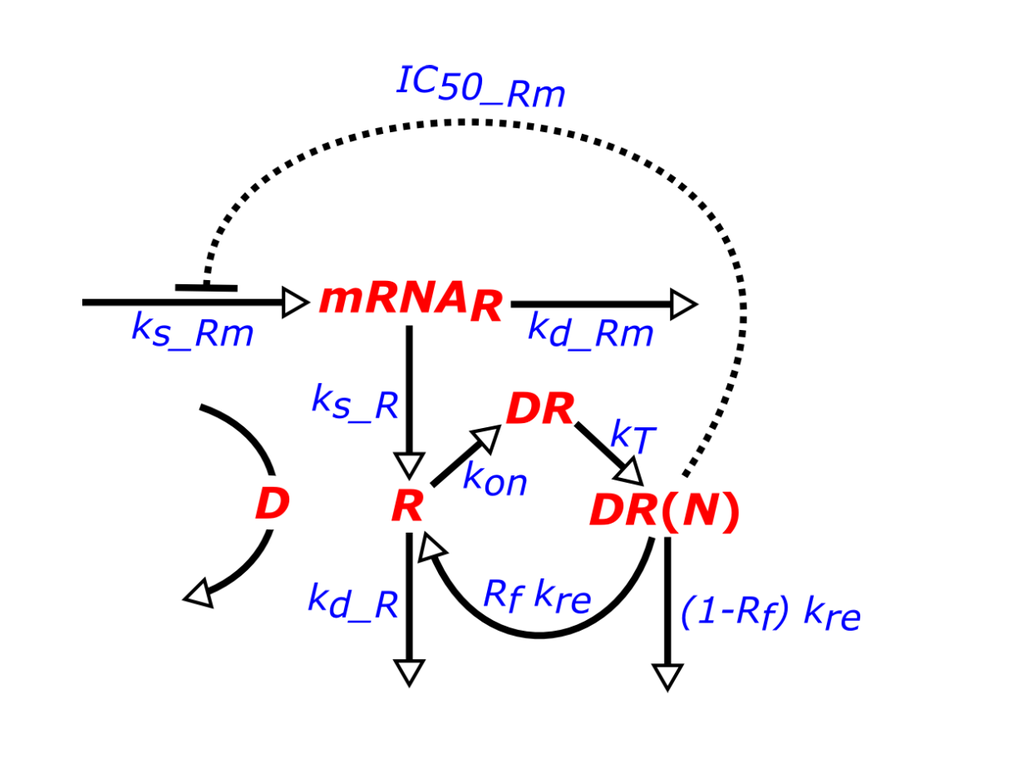

Flowchart van glucocoritcoide receptor dynamica

Uit dit model is af te leiden dat de concentratie voor receptor mRNA zo te berekenen valt.

$$\frac{dmRNA_R}{dt} = k_{s\_Rm} *(1-\frac{DR(N)}{IC_{50\_Rm + DR(N)}}) -k_{d\_Rm} * mRNA_R$$
De concentratie vrije receptor(R) is als volgt af te leiden:
$$\frac{dR}{dt} = k_{s\_R} * mRNA_R + R_f * k_{re} * DR(N) - k_{on} * D * R - k_{d\_R} * R$$

De concentratie receptor complex(DR) is als volgt af te leiden:
$$\frac{dDR}{dt} = k_{on} * D *R - k_t * DR$$

De concentratie receptor complex(DR(N)) in de kern is als volgt af te leiden:
$$\frac{dDR(N)}{dt} = k_t * DR - k_{re} * DR(N)$$

# Methode

## Het software model

Gebruikt in dit model is R (versie 4.0.4) met de deSolve library (versie 1.28), en pander (versie 0.6.4) voor de tabellen. Het volgende model is gebruikt.

```r
library(deSolve)

# Define model
glucocorticoid <- function(t,state,parms){
  with(as.list(c(parms)),{
  dRmO <- ks_Rm * (1 - state[4] / (IC50_Rm + state[4])) - kd_Rm * state[1]
  dRO <- ks_r * state[1] + Rf * kre * state[4] - kon * D * state[2] - kd_R * state[2]
  dDR <- kon * D * state[2] - kT * state[4]
  dDR_N <- kT * state[3] - kre * state[4]
  return(list(c(dRmO, dRO, dDR, dDR_N)))})}
```

## Model configuratie

```r
values <- read.csv("parameters.txt", header = T)
pander(values)
```

| Parameters | waardes |
| --- | --- |
| ks_Rm (fmol/g liver/h) | 2.9 |
| IC50_Rm (fmol/mg protein) | 26.2 |
| kon (L/nmol/h) | 0.00329 |
| kT (1 / h) | 0.63 |
| kre (1 / h) | 0.57 |
| Rf | 0.49 |
| kd_R (1 / h) | 0.0572 |
| kd_Rm | 0.612 |
| ks_r | 3.22 |
| D (nmol/L) | 0 |

```r
ini_values <- read.csv("initiele.txt", header = T)
pander(ini_values)
```

| Inietiele.waarde | waarde |
| --- | --- |
| Rm0 (fmol / g liver) | 4.74 |
| R0 (fmol/mg protein) | 267 |
| DR (fmol/mg protein) | 0 |
| DR(N) (fmol/mg protein) | 0 |

```r
data <- read.csv("MPL.csv", na.strings = "NA")
median_MPL_01 <- median(data$MPL_conc[data$dose==0.1], na.rm=T)
median_MPL_01 <- median_MPL_01*1000/374.471

median_MPL_03 <- median(data$MPL_conc[data$dose==0.3], na.rm = T)
median_MPL_03 <- median_MPL_03*1000/374.471
```

Deze parameters zijn gebaseerd op een aantal experimenten uitgevoerd op ratten die MPL kregen toegediend.De concentratie MPL (D) is in dit model constant over de 7 dagen. Voor de waarde D wordt de mediaan van MPL concentratie uit de experimenten gebruikt.

```r
# Time
times <- seq(0, 168, by = 1)

# Define initial values
state <- c(RmO=4.74, RO =267, DR=0, DR_N=0)

#Set parameters of dose 0.1
parameters <- c(ks_Rm =2.90, IC50_Rm =26.2, kon =0.00329, kT =0.63,
                kre=0.57, Rf=0.49, kd_R=0.0572, kd_Rm=0.612, ks_r=3.22, D = median_MPL_01)
dose_1 <- ode(times = times, y = state, parms = parameters, func = glucocorticoid)

#Set parameters of dose 0.3
parameters <- c(ks_Rm =2.90, IC50_Rm =26.2, kon =0.00329, kT =0.63,
                kre=0.57, Rf=0.49, kd_R=0.0572, kd_Rm=0.612, ks_r=3.22, D = median_MPL_03)
dose_3 <- ode(times = times, y = state, parms = parameters, func = glucocorticoid)
```

# Resultaten

## Valideren van het model

Om dat het model per uur maar 1 waarde heeft maar de data niet is eerst de mediaan uitgerekend per tijdseenheid.

```r
medians <- aggregate(data[,c("MPL_conc","mRNA","Free_receptor")],
list(data$dose,data$time),median, na.rm=TRUE)
names(medians)[1:2] <- c("dose","time")
```

Vervolgens is dit geplot.

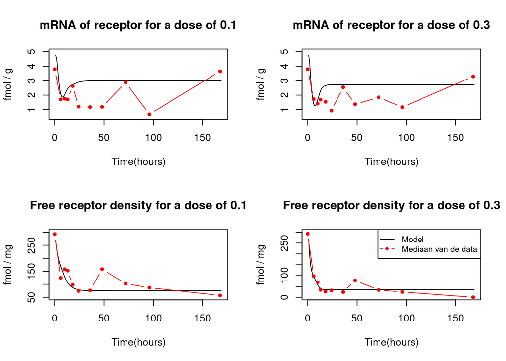

```r
layout(matrix(c(1 ,2, 3, 4), ncol = 2, nrow = 2, byrow = TRUE))

plot(dose_1[,"RmO"], type = "l", ylim = c(0.5, 5), main = "mRNA of receptor for a dose of 0.1",
     xlab = "Time(hours)", ylab = "fmol / g")
points(medians$mRNA[medians$dose == 0.1 | medians$dose == 0.0]~
         medians$time[medians$dose == 0.1| medians$dose == 0.0]
       ,pch = 20, type = "b", col = "red")

plot(dose_3[,"RmO"], type = "l", ylim = c(0.5, 5), main = "mRNA of receptor for a dose of 0.3"
     ,xlab = "Time(hours)", ylab = "fmol / g")
points(medians$mRNA[medians$dose == 0.3 | medians$dose == 0.0]~
         medians$time[medians$dose == 0.3| medians$dose == 0.0]
       ,pch = 20, type = "b", col = "red")

plot(dose_1[,"RO"], type = "l", main = "Free receptor density for a dose of 0.1",
     xlab = "Time(hours)", ylab = "fmol / mg", ylim = c(50, 300))
points(medians$Free_receptor[medians$dose == 0.1 | medians$dose == 0.0]~
         medians$time[medians$dose == 0.1| medians$dose == 0.0]
       ,pch = 20, type = "b", col = "red")

plot(dose_3[,"RO"], type = "l", main = "Free receptor density for a dose of 0.3"
     ,xlab = "Time(hours)", ylab = "fmol / mg", ylim = c(0, 300))
points(medians$Free_receptor[medians$dose == 0.3 | medians$dose == 0.0]~
         medians$time[medians$dose == 0.3| medians$dose == 0.0]
       ,pch = 20, type = "b", col = "red")

legend("topright", legend=c("Model", "Mediaan van de data"),
       col=c("black", "red"), lty=1:2, cex=0.8, pch = c(NA, 20))
```

Terwijl het model bij het receptor mRNA stabiliseerd is er te zien dat bij de data van de experimenten dit niet zo is. De data van de experimenten heeft meer sterke stijgingen en dalingen in de verandering van de concentratie mRNA receptor. Voor de dose 0.1 de mRNA concentratie in de experiment data lijkt het tussen de 25 en 50 uur stabiel te zien maar na de 50 uur zijn er vaker sterke stijgingen en daling. Bij een dose van 0.3 lijken de stijgingen en daling minder sterk, maar ligt de lijn ook nooit stabiel.

De vergelijking tussen het model en de vrije receptor dichtheid bij een dose van 0.1 lijkt beter aangesloten bij elkaar. Het model laat in de eerste paar uur alleen maar een daling zien, terwijl in de data hier wel een kleine stijging tussen zit. Ook laat het model alleen maar een stabiele lijn zien na ongeveer 40 uur vergeleken met het model dit rond de 40 uur nog een stijging laat zien om vervolgens weer langzaam te dalen. Bij de vergelijkingen tussen het model en de data met een dose van 0.3 is eerst een daling in beide gevallen. Waar deze met elkaar verschillen is weer rond de 40 uur waar er ook bij een dose van 0.3 een stijging is, alhoewel deze stijging minder sterk lijkt te zien, vervolgens daalt de verandering in de vrije receptor dichtheid langzaam weer af.

## Simulaties met het model

Hieronder worden verschillende simulaties van het model gedaan om te kijken wat het effect van deze situaties zijn op de verschillende initiele waardes.

### Situatie: Geen auto regulatie

Om te kijken hoe de resultaten veranderen wanneer er geen auto-regulatie meer plaats vindt is hieronder de tijdsafhankelijkheid van het geactiveerde complex weergegeven wanneer er geen auto-regulatie van de glucocorticoide receptor weergegeven. De medicatie (MPL) heeft nu dus geen effect op de synthese van het receptor mRNA. Het model wordt eerst aangepast door de IC50_Rm waarde eruit te halen.

```r
# Gedefinieerd model:
glucocorticoid <- function(t,state,parms){
  with(as.list(c(state, parms)),{

    dmRNAR <- ks_Rm - kd_Rm * Rm0
    dR <- ks_R * Rm0 + Rf * kre * DR_N - kon * D * R0 - kd_R * R0
    dDR <- kon * D * R0 - kT * DR
    dDR_N <- kT * DR - kre * DR_N
    return(list(c(dmRNAR, dR, dDR, dDR_N)))
  }
  )
}
```

```r
# Parameters
parameters <- c(ks_Rm=2.9, kd_Rm=0.612, ks_R=3.22, kd_R=0.0572, kon=0.00329, kT=0.63, kre=0.57, Rf=0.49, IC50_Rm=26.2, D=53.41)
# Begin waarden
state = c(Rm0=4.74, R0=267, DR=0, DR_N=0)
# Timeframe
t = seq(0, 48, 1)
```

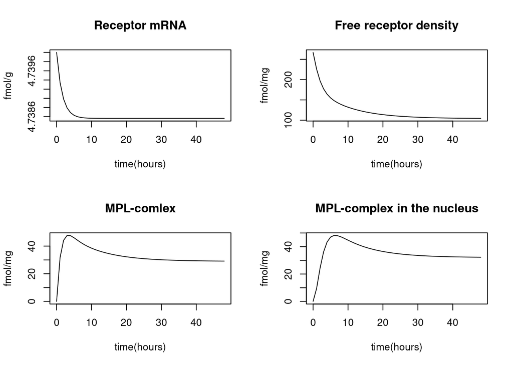

Uitkomsten van het model wanneer de auto-regulatie weggehaald is uit het model. Te zien is dat de concentratie mRNA eerst daalt maar vervolgens stabiel blijft. De dichtheid van de vrije receptor gaat langzaam naar beneden totdat dit ook stabiel ligt. Zowel het MPL-complex in het cytoplasma als het MPL-complex in de kern stijging eerst sterk totdat ze langzaam aan een klein beetje dalen, vervolgens liggen ze stabiel.

```r
# Uitwerking model m.b.v. ode functie:
out <- ode(y=state, times=t, func=glucocorticoid, parms=parameters)
plot(out, main = c("Receptor mRNA", "Free receptor density", "MPL-comlex",
                   "MPL-complex in the nucleus"),
     ylab = c("fmol/g", "fmol/mg","fmol/mg", "fmol/mg"), xlab = "time(hours)")
```

De verandering van de concentratie van het mRNA van de receptor is veel lager dan het orginele model. De auto regulatie is er immers af dus deze daling is alleen te danken aan het feit dat mRNA ook automatisch het systeem verlaat.

### Situatie: Medicatie wordt gestopt

Hieronder wordt de tijdsafhankelijkheid van de receptor mRNA concentratie wanneer er gestopt wordt met de medicatie weergegeven. Nadat de de reacties gestabiliseerd zijn, steady state, wordt de D waarde op 0 gezet. Hierna wordt een nieuwe evenwichtsverhouding gevormd: t_steady_second.

```r
# Gedefinieerd model:
glucocorticoid <- function(t,state,parms){
  with(as.list(c(state, parms)),{
    dmRNAR <- ks_Rm * (1 - DR_N/(IC50_Rm + DR_N)) - kd_Rm * Rm0
    dR <- ks_R * Rm0 + Rf * kre * DR_N - kon * D * R0 - kd_R * R0
    dDR <- kon * D * R0 - kT * DR
    dDR_N <- kT * DR - kre * DR_N
    return(list(c(dmRNAR, dR, dDR, dDR_N)))
  }
  )
}
```

```r
# Parameters
parameters <- c(ks_Rm=2.9, kd_Rm=0.612, ks_R=3.22, kd_R=0.0572, kon=0.00329, kT=0.63, kre=0.57, Rf=0.49, IC50_Rm=26.2, D=53.41)
# Begin waarden
state <- c(Rm0=4.74, R0=267, DR=0, DR_N=0)
# Timeframe
t <- seq(0, 48, 1)
```

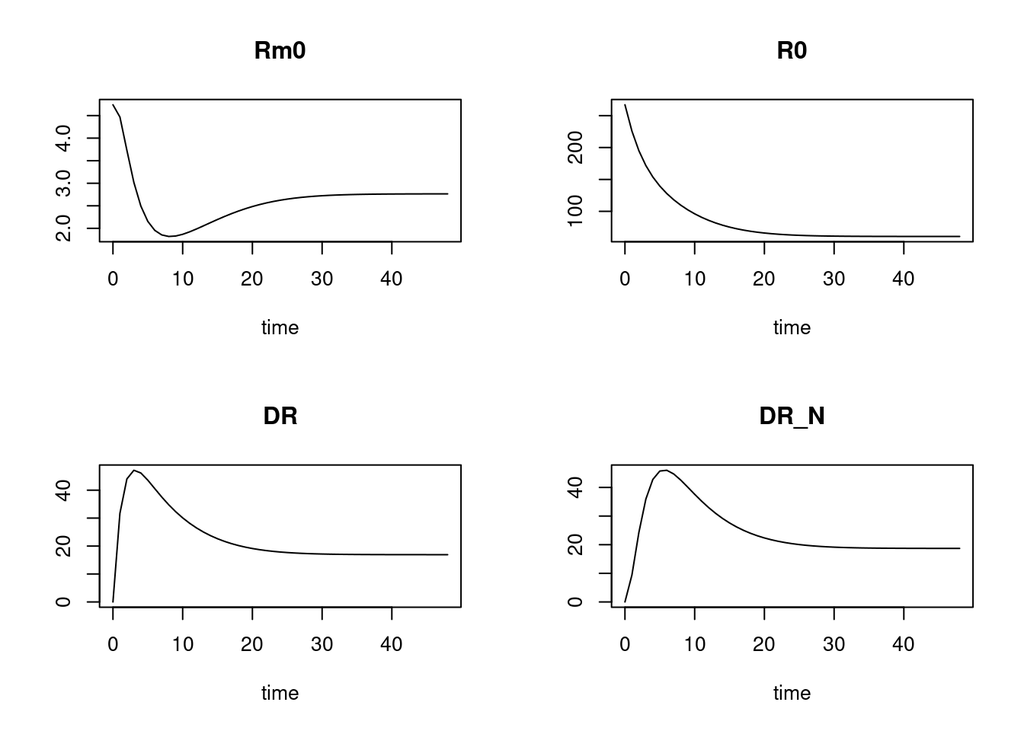

```r
# Uitwerking model m.b.v. ode functie:
out <- ode(y=state, times=t, func=glucocorticoid, parms=parameters)
plot(out)
```

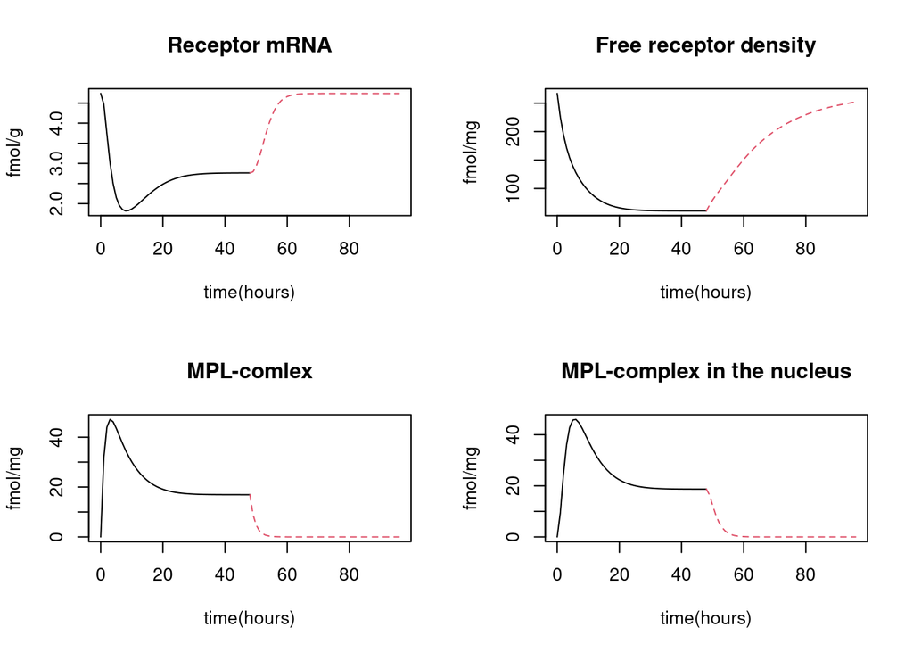

Weergegeven is het model wanneer er plotesling gestopt wordt met de medicatie nadat de steady state bereikt is. Met rood stippelijn is de situatie zonder medicatie. Bij de concentraie van het mRNA en de dichtheid van het vrije receptor is er te zien dat dit al vrij snel weer omhoog gaat. Bij het MPL-complex in het cytoplasma en het MPL-complex in de kern daalt het vrij sterk om vervolgens weer stabiel te liggen.

```r
parameters[10] <- 0
steady_state <- 48
state <- out[steady_state, c("Rm0", "R0", "DR", "DR_N")]
t <- seq(steady_state, steady_state+steady_state, 1)
out_2 <- ode(y=state, times=t, func=glucocorticoid, parms=parameters)
plot(out, out_2, main=c("Receptor mRNA", "Free receptor density",
                        "MPL-comlex","MPL-complex in the nucleus"),
     ylab = c("fmol/g", "fmol/mg","fmol/mg", "fmol/mg"), xlab = "time(hours)")
```

Er is te zien dat wanneer de auto regulatie van het model afgehaald wordt, dat alle waardes langzaam terug gaan naar de waardes van het begin. Nadat deze waardes bereikt zijn stabieliseren de waardes en hebben ze dus een steady state bereikt.

## Situatie: ‘rate of association’ en ‘rate of dissociation’ wordt aangepast.

Er zijn verschillende corticosteroiden die je als medicijn kunt gebruiken. Ze verschillen in hun kon rate, dit is de snelheid waarmee ze de receptoren herkennen en hun kre rate, dit is de snelheid waarmee het complex weer uit elkaar valt. Er zal worden gekeken wat het effect van verschillende kon en kre rates voor invloed hebben om de receptor en mRNA dynamics. We gaan kijken naar een 2x en 5x verhoging en verlaging van beide rates.

```r
# Gedefinieerd model:
glucocorticoid <- function(t,state,parms){
  with(as.list(c(state, parms)),{
    dmRNAR <- ks_Rm * (1 - DR_N/(IC50_Rm + DR_N)) - kd_Rm * Rm0
    dR <- ks_R * Rm0 + Rf * kre * DR_N - kon * D * R0 - kd_R * R0
    dDR <- kon * D * R0 - kT * DR
    dDR_N <- kT * DR - kre * DR_N
    return(list(c(dmRNAR, dR, dDR, dDR_N)))
  }
  )
}
```

```r
# Parameters
parameters <- c(ks_Rm=2.9, kd_Rm=0.612, ks_R=3.22, kd_R=0.0572, kon=0.00329, kT=0.63, kre=0.57, Rf=0.49, IC50_Rm=26.2, D=53.41)
# Begin waarden
state <- c(Rm0=4.74, R0=267, DR=0, DR_N=0)
# Timeframe
t <- seq(0, 48, 1)
```

#### Versie 0: normale werking

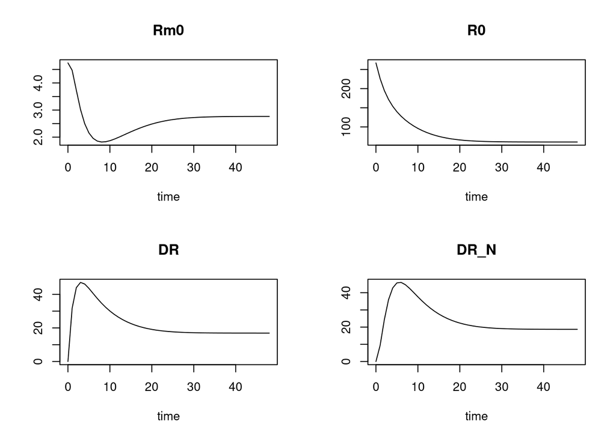

Te zijn hierboven is het model zonder aanpassing van de waardes. De association rate en de dissociation rate zijn de eerder gezette standaard. Te zien in de grafiek is dat de concentratie van het mRNA eerst sterk daalt, langzaam weer stijgt en uiteindelijk stabieliseerd. De dichtheid in de vrije receptor daalt langzaam en valt uiteindelijk ook in een steady state. Voor zowel de concentratie van het MPL-complex binnen en buiten de kern geldt eerst een stijging en vervolgens een daling waarna het ook in een steady state valt.

```r
# Uitwerking model m.b.v. ode functie:
out <- ode(y=state, times=t, func=glucocorticoid, parms=parameters)
plot(out)
```

#### Versie 1: k on : 0.00329/5, 0.00329/2, 0.00329*2 and 0.00329*5

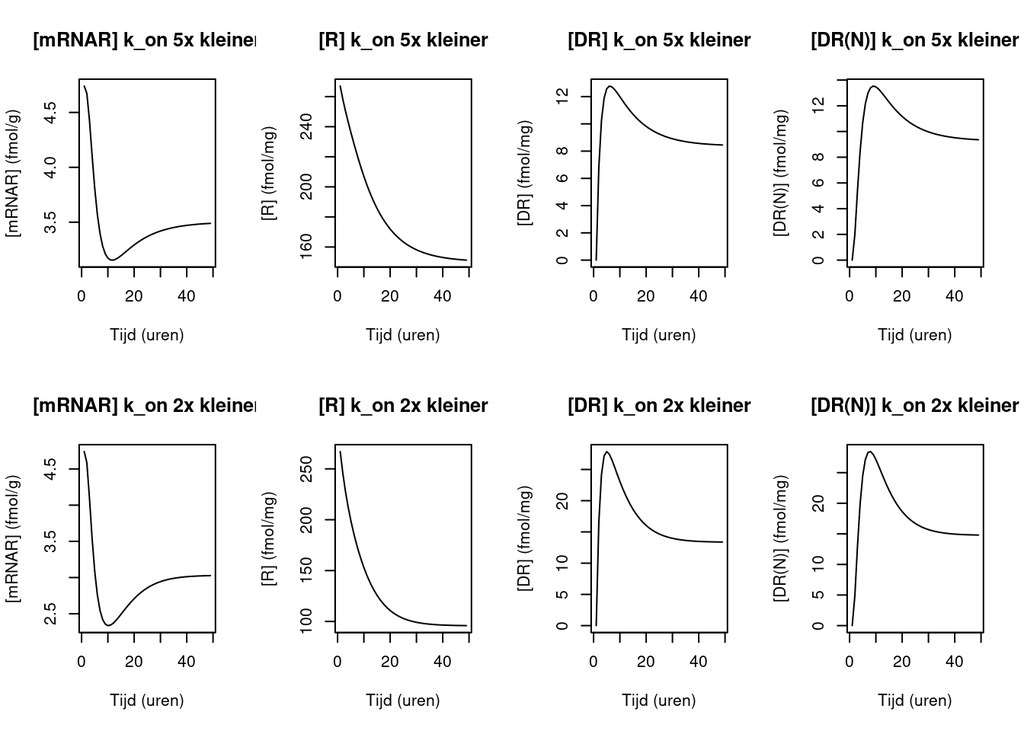

In de figuren hieronder is te zien wat er gebeurt met de 4 eerder genoemde factoren wanneer k_on 2x en 5x kleiner is en daarna 2x en 5x groter is. Voor wanneer de k_on kleiner is geldt een daling voor het mRNA van de receptor, een meer geleidelijke daling van de vrije receptor dichtheid. Voor zowel de concentratie van het MPL-complex binnen en buiten de kern geldt eerst een sterke stijging, gevolgd door een daling, en vervolgens wordt weer een steady state bereikt. Wanneer k_on groter wordt gemaakt wordt er een sterkere daling gezien in het mRNA van de receptor aan het begin maar ook een snellere stijging en dus wordt ook de steady state sneller bereikt. De dichtheid van het vrije receptor daalt sterk en bereikt de steady state eerder. Voor zowel de concentratie van het MPL-complex binnen en buiten de kern geldt een erg sterke stijging in concentratie gevolgd door een sterke daling waarna het de steady state bereikt.

```r
par(mfrow = c(2, 4))
parameters[5] <- 0.00329/5
out <- ode(y=state, times=t, func=glucocorticoid, parms=parameters)
plot(out[, "Rm0"], type = "l", main = "[mRNAR] k_on 5x kleiner", ylab="[mRNAR] (fmol/g)", xlab= "Tijd (uren)")
plot(out[, "R0"], type = "l", main = "[R] k_on 5x kleiner", ylab="[R] (fmol/mg)", xlab= "Tijd (uren)")
plot(out[, "DR"], type = "l", main = "[DR] k_on 5x kleiner", ylab="[DR] (fmol/mg)", xlab= "Tijd (uren)")
plot(out[, "DR_N"], type = "l", main = "[DR(N)] k_on 5x kleiner", ylab="[DR(N)] (fmol/mg)", xlab= "Tijd (uren)")
parameters[5] <- 0.00329/2
out <- ode(y=state, times=t, func=glucocorticoid, parms=parameters)
plot(out[, "Rm0"], type = "l", main = "[mRNAR] k_on 2x kleiner", ylab="[mRNAR] (fmol/g)", xlab= "Tijd (uren)")
plot(out[, "R0"], type = "l", main = "[R] k_on 2x kleiner", ylab="[R] (fmol/mg)", xlab= "Tijd (uren)")
plot(out[, "DR"], type = "l", main = "[DR] k_on 2x kleiner", ylab="[DR] (fmol/mg)", xlab= "Tijd (uren)")
plot(out[, "DR_N"], type = "l", main = "[DR(N)] k_on 2x kleiner", ylab="[DR(N)] (fmol/mg)", xlab= "Tijd (uren)")
```

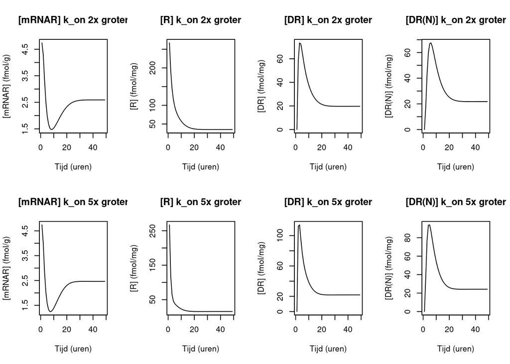

In de figuren hieronder is te zien wat er gebeurt met de 4 eerder genoemde factoren wanneer k_on 2x en 5x kleiner is en daarna 2x en 5x groter is. Voor wanneer de k_on kleiner is geldt een daling voor het mRNA van de receptor, een meer geleidelijke daling van de vrije receptor dichtheid. Voor zowel de concentratie van het MPL-complex binnen en buiten de kern geldt eerst een sterke stijging, gevolgd door een daling, en vervolgens wordt weer een steady state bereikt. Wanneer k_on groter wordt gemaakt wordt er een sterkere daling gezien in het mRNA van de receptor aan het begin maar ook een snellere stijging en dus wordt ook de steady state sneller bereikt. De dichtheid van het vrije receptor daalt sterk en bereikt de steady state eerder. Voor zowel de concentratie van het MPL-complex binnen en buiten de kern geldt een erg sterke stijging in concentratie gevolgd door een sterke daling waarna het de steady state bereikt.

```r
par(mfrow = c(2, 4))
parameters[5] <- 0.00329*2
out <- ode(y=state, times=t, func=glucocorticoid, parms=parameters)
plot(out[, "Rm0"], type = "l", main = "[mRNAR] k_on 2x groter", ylab="[mRNAR] (fmol/g)", xlab= "Tijd (uren)")
plot(out[, "R0"], type = "l", main = "[R] k_on 2x groter", ylab="[R] (fmol/mg)", xlab= "Tijd (uren)")
plot(out[, "DR"], type = "l", main = "[DR] k_on 2x groter", ylab="[DR] (fmol/mg)", xlab= "Tijd (uren)")
plot(out[, "DR_N"], type = "l", main = "[DR(N)] k_on 2x groter", ylab="[DR(N)] (fmol/mg)", xlab= "Tijd (uren)")
parameters[5] <- 0.00329*5
out <- ode(y=state, times=t, func=glucocorticoid, parms=parameters)
plot(out[, "Rm0"], type = "l", main = "[mRNAR] k_on 5x groter", ylab="[mRNAR] (fmol/g)", xlab= "Tijd (uren)")
plot(out[, "R0"], type = "l", main = "[R] k_on 5x groter", ylab="[R] (fmol/mg)", xlab= "Tijd (uren)")
plot(out[, "DR"], type = "l", main = "[DR] k_on 5x groter", ylab="[DR] (fmol/mg)", xlab= "Tijd (uren)")
plot(out[, "DR_N"], type = "l", main = "[DR(N)] k_on 5x groter", ylab="[DR(N)] (fmol/mg)", xlab= "Tijd (uren)")
```

Bij het groter worden van de ‘rate of association’ wordt er ook gezien dat de dichtheid van de vrije receptor sneller daalt.

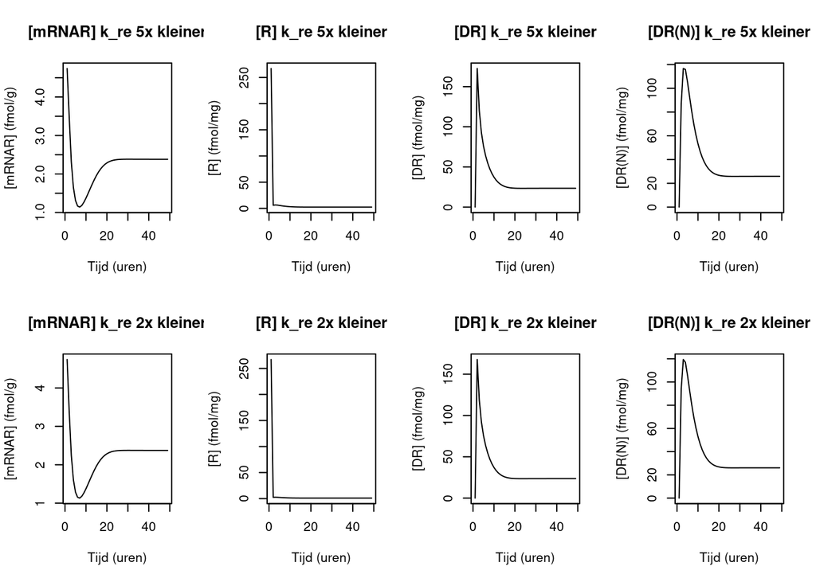

```r
parameters <- c(ks_Rm=2.9, kd_Rm=0.612, ks_R=3.22, kd_R=0.0572, kon=0.00329, kT=0.63, kre=0.57, Rf=0.49, IC50_Rm=26.2, D=53.41)
par(mfrow = c(2, 4))
parameters[5] <- 0.57/5
out <- ode(y=state, times=t, func=glucocorticoid, parms=parameters)
plot(out[, "Rm0"], type = "l", main = "[mRNAR] k_re 5x kleiner", ylab="[mRNAR] (fmol/g)", xlab= "Tijd (uren)")
plot(out[, "R0"], type = "l", main = "[R] k_re 5x kleiner", ylab="[R] (fmol/mg)", xlab= "Tijd (uren)")
plot(out[, "DR"], type = "l", main = "[DR] k_re 5x kleiner", ylab="[DR] (fmol/mg)", xlab= "Tijd (uren)")
plot(out[, "DR_N"], type = "l", main = "[DR(N)] k_re 5x kleiner", ylab="[DR(N)] (fmol/mg)", xlab= "Tijd (uren)")
parameters[5] <- 0.57/2
out <- ode(y=state, times=t, func=glucocorticoid, parms=parameters)
plot(out[, "Rm0"], type = "l", main = "[mRNAR] k_re 2x kleiner", ylab="[mRNAR] (fmol/g)", xlab= "Tijd (uren)")
plot(out[, "R0"], type = "l", main = "[R] k_re 2x kleiner", ylab="[R] (fmol/mg)", xlab= "Tijd (uren)")
plot(out[, "DR"], type = "l", main = "[DR] k_re 2x kleiner", ylab="[DR] (fmol/mg)", xlab= "Tijd (uren)")
plot(out[, "DR_N"], type = "l", main = "[DR(N)] k_re 2x kleiner", ylab="[DR(N)] (fmol/mg)", xlab= "Tijd (uren)")
```

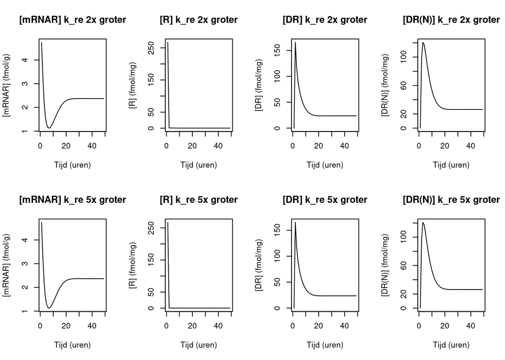

```r
par(mfrow = c(2, 4))
parameters[5] <- 0.57*2
out <- ode(y=state, times=t, func=glucocorticoid, parms=parameters)
plot(out[, "Rm0"], type = "l", main = "[mRNAR] k_re 2x groter", ylab="[mRNAR] (fmol/g)", xlab= "Tijd (uren)")
plot(out[, "R0"], type = "l", main = "[R] k_re 2x groter", ylab="[R] (fmol/mg)", xlab= "Tijd (uren)")
plot(out[, "DR"], type = "l", main = "[DR] k_re 2x groter", ylab="[DR] (fmol/mg)", xlab= "Tijd (uren)")
plot(out[, "DR_N"], type = "l", main = "[DR(N)] k_re 2x groter", ylab="[DR(N)] (fmol/mg)", xlab= "Tijd (uren)")
parameters[5] <- 0.57*5
out <- ode(y=state, times=t, func=glucocorticoid, parms=parameters)
plot(out[, "Rm0"], type = "l", main = "[mRNAR] k_re 5x groter", ylab="[mRNAR] (fmol/g)", xlab= "Tijd (uren)")
plot(out[, "R0"], type = "l", main = "[R] k_re 5x groter", ylab="[R] (fmol/mg)", xlab= "Tijd (uren)")
plot(out[, "DR"], type = "l", main = "[DR] k_re 5x groter", ylab="[DR] (fmol/mg)", xlab= "Tijd (uren)")
plot(out[, "DR_N"], type = "l", main = "[DR(N)] k_re 5x groter", ylab="[DR(N)] (fmol/mg)", xlab= "Tijd (uren)")
```

### Situatie: Synthese mRNA wordt geblokkeerd

In de volgende simulatie wordt weergegeven wat de gevolgen van de dynamica in het model zullen zijn wanneer de synthese van het receptor mRNA wordt geblokkeerd. De ks_Rm rate zal 0 zijn, omdat er geen enkele synthese meer zal plaatsvinden.

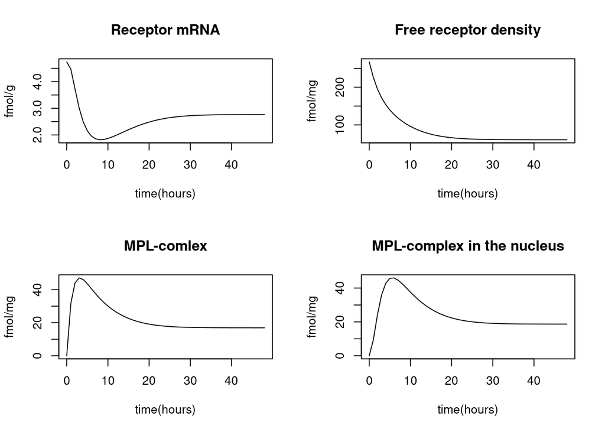

```r
# Normale werking:
parameters <- c(ks_Rm=2.9, kd_Rm=0.612, ks_R=3.22, kd_R=0.0572, kon=0.00329, kT=0.63, kre=0.57, Rf=0.49, IC50_Rm=26.2, D=53.41)
out <- ode(y=state, times=t, func=glucocorticoid, parms=parameters)
plot(out, main=c("Receptor mRNA", "Free receptor density",
                        "MPL-comlex","MPL-complex in the nucleus"),
     ylab = c("fmol/g", "fmol/mg","fmol/mg", "fmol/mg"), xlab = "time(hours)")
```

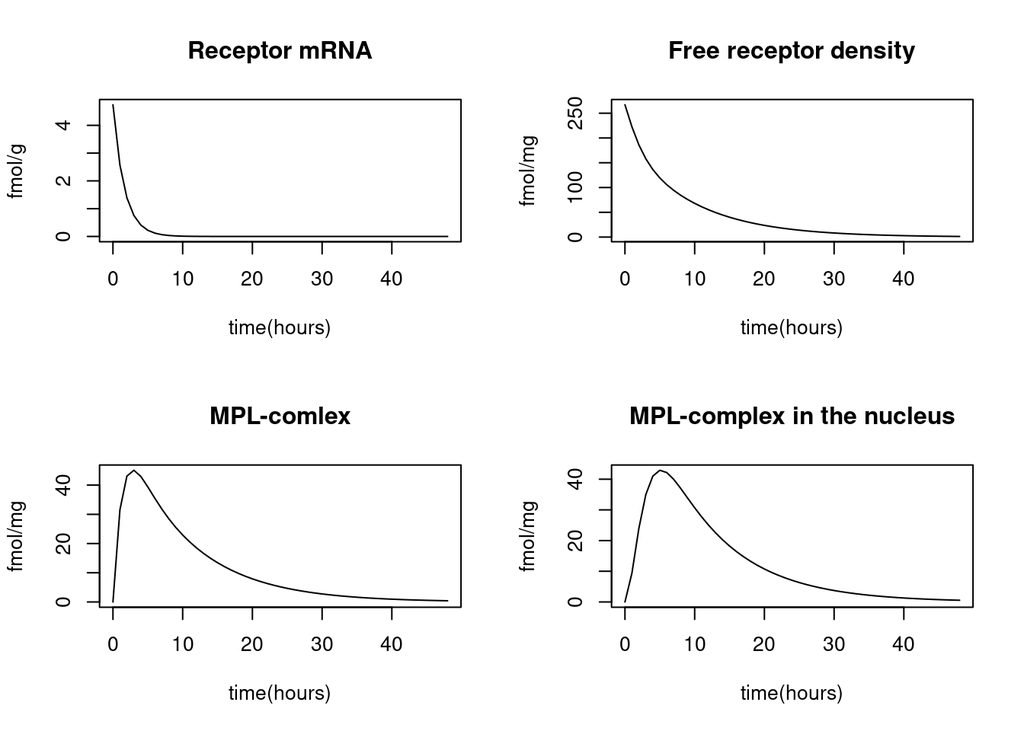

In het figuur is eerst te zien hoe het figuur er uit ziet on normale condities zoals eerder beschreven. Ook is te zien hoe het model eruit wanneer synthese compleet stopt. Wanneer dit gebeurt is te zien hoe het mRNA van de receptor eerst daalt net zoals het originele model maar vervolgens daalt. De steady state wordt pas bereikt bij de 0. In de dichtheid van het vrije receptor complex zien we hetzelfde patroon, een langzame daling waarna het een steady state raakt. Bij het MPL-complex in het cytoplasma en in de kern wordt eerst een sterke stijging gezien vervolgens een langzame daling totdat het de steady state raakt bij de 0.

```r
# Verstoorde werking door stoppen van de receptor RNA synthese.
parameters[1] <- 0
out <- ode(y=state, times=t, func=glucocorticoid, parms=parameters)
plot(out, main=c("Receptor mRNA", "Free receptor density",
                        "MPL-comlex","MPL-complex in the nucleus"),
     ylab = c("fmol/g", "fmol/mg","fmol/mg", "fmol/mg"), xlab = "time(hours)")
```

Als er geen synthese meer plaatsvindt in het model betekent dit dat de concentratie van mRNA om 0 blijft en niet meer omhoog komt, er wordt immers geen mRNA meer gemaakt dus wanneer alles gebonden is of gewoon uit het systeem gaat is er geen manier meer op er meer bij te krijgen. Uiteindelijk betekent dit dat alles langzaam naar 0 gaat, zonder mRNA kan er geen receptor meer gemaakt worden en zal er dus ook geen complex meer binden.

### Situatie: Aanmaak mRNA wordt verhoogt

Wanneer de aanmaak van mRNA (ks_Rm) met 2x of 5x verhoogt, zal dit ook de mRNA afbraak (kd_Rm) rate verhogen omdat er nu meer mRNAR aanwezig is. Deze verhouding hoort in evenwicht te zijn. Hieronder zullen de effecten van zo’n situatie op de dynamica van ons model weergegeven worden. Daarvoor zullen de mRNA aanmaak (ks_Rm) en mRNA afbraak (kd_Rm) parameters dus aangepast moeten worden.

```r
# Gedefinieerd model:
glucocorticoid <- function(t,state,parms){
  with(as.list(c(state, parms)),{
    dmRNAR <- ks_Rm * (1 - DR_N/(IC50_Rm + DR_N)) - kd_Rm * Rm0
    dR <- ks_R * Rm0 + Rf * kre * DR_N - kon * D * R0 - kd_R * R0
    dDR <- kon * D * R0 - kT * DR
    dDR_N <- kT * DR - kre * DR_N
    return(list(c(dmRNAR, dR, dDR, dDR_N)))
  }
  )
}
```

```r
# Parameters
parameters <- c(ks_Rm=2.9, kd_Rm=0.612, ks_R=3.22, kd_R=0.0572, kon=0.00329, kT=0.63, kre=0.57, Rf=0.49, IC50_Rm=26.2, D=53.41)
# Begin waarden
state <- c(Rm0=4.74, R0=267, DR=0, DR_N=0)
# Timeframe
t <- seq(0, 48, 1)
```

### Versie 0: normale werking

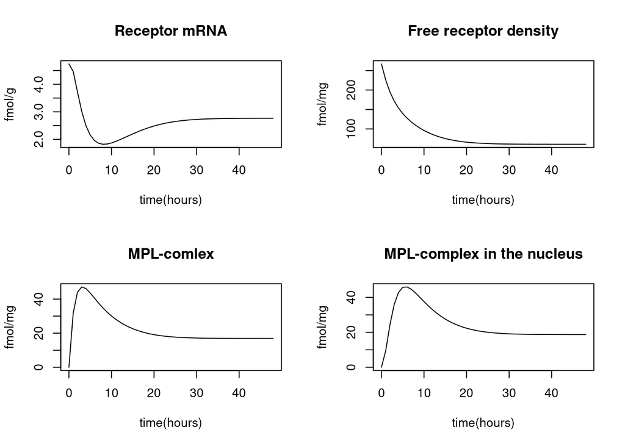

```r
# Uitwerking model m.b.v. ode functie:
out <- ode(y=state, times=t, func=glucocorticoid, parms=parameters)
plot(out, main=c("Receptor mRNA", "Free receptor density",
                        "MPL-comlex","MPL-complex in the nucleus"),
     ylab = c("fmol/g", "fmol/mg","fmol/mg", "fmol/mg"), xlab = "time(hours)")
```

#### Versie 1: ks_Rm 5x zo klein:

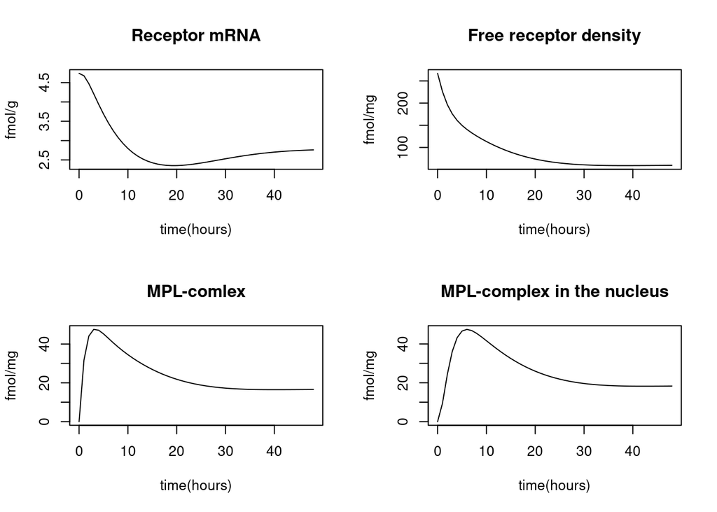

Wanneer de aanmaak en afbraak van het mRNA 5x zo klein wordt dan is er te zien dat de concentratie van het receptor mRNA langzaam daalt, vervolgens weer voorzichtig stijgt. Er wordt geen steady state bereikt. In de dichtheid van de vrije receptor zien we een daling totdat de steady state bereikt wordt. Het MPL-complex in zowel het cytoplasma als het complex in de kern ziet eerst een sterke stijging, vervolgens een voorzichtige daling, waarna de steady state bereikt wordt.

```r
parameters[1] <- 2.9/5
parameters[2] <- 2.9/5/4.74
out <- ode(y=state, times=t, func=glucocorticoid, parms=parameters)
plot(out, main=c("Receptor mRNA", "Free receptor density",
                        "MPL-comlex","MPL-complex in the nucleus"),
     ylab = c("fmol/g", "fmol/mg","fmol/mg", "fmol/mg"), xlab = "time(hours)")
```

#### Versie 2: ks_Rm 2x zo klein:

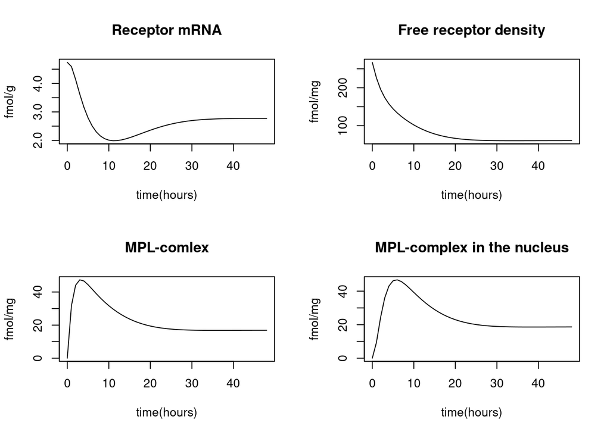

Wanneer de aanmaak en afbraak van het mRNA 2x zo klein wordt dan is er te zien dat de concentratie van het receptor mRNA langzaam daalt, vervolgens weer voorzichtig stijgt en dan een steady state bereikt. In de dichtheid van de vrije receptor zien we een daling totdat de steady state bereikt wordt. Het MPL-complex in zowel het cytoplasma als het complex in de kern ziet eerst een sterke stijging, vervolgens een voorzichtige daling, waarna de steady state bereikt wordt.

```r
parameters[1] <- 2.9/2
parameters[2] <- 2.9/2/4.74
out <- ode(y=state, times=t, func=glucocorticoid, parms=parameters)
plot(out, main=c("Receptor mRNA", "Free receptor density",
                        "MPL-comlex","MPL-complex in the nucleus"),
     ylab = c("fmol/g", "fmol/mg","fmol/mg", "fmol/mg"), xlab = "time(hours)")
```

Wanneer de ks_Rm kleiner wordt zien we dat het langer duurt voordat de concentratie van het mRNA een steady state vormt. Hoe kleiner de waarde, hoe langer dit zal duren.

#### Versie 3: ks_Rm 2x zo groot:

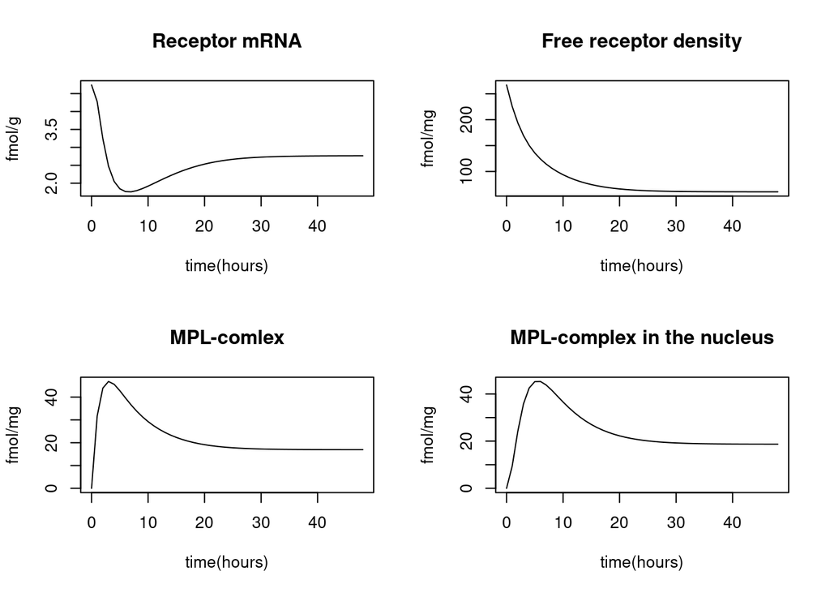

Wanneer de aanmaak en afbraak van het mRNA 2x zo groot wordt dan is er te zien dat de concentratie van het receptor mRNA langzaam daalt, vervolgens weer voorzichtig stijgt en dan een steady state bereikt. In de dichtheid van de vrije receptor zien we een daling totdat de steady state bereikt wordt. Het MPL-complex in zowel het cytoplasma als het complex in de kern ziet eerst een sterke stijging, vervolgens een voorzichtige daling, waarna de steady state bereikt wordt.

```r
parameters[1] <- 2.9*2
parameters[2] <- 2.9*2/4.74
out <- ode(y=state, times=t, func=glucocorticoid, parms=parameters)
plot(out, main=c("Receptor mRNA", "Free receptor density",
                        "MPL-comlex","MPL-complex in the nucleus"),
     ylab = c("fmol/g", "fmol/mg","fmol/mg", "fmol/mg"), xlab = "time(hours)")
```

#### Versie 4: ks_Rm 5x zo groot:

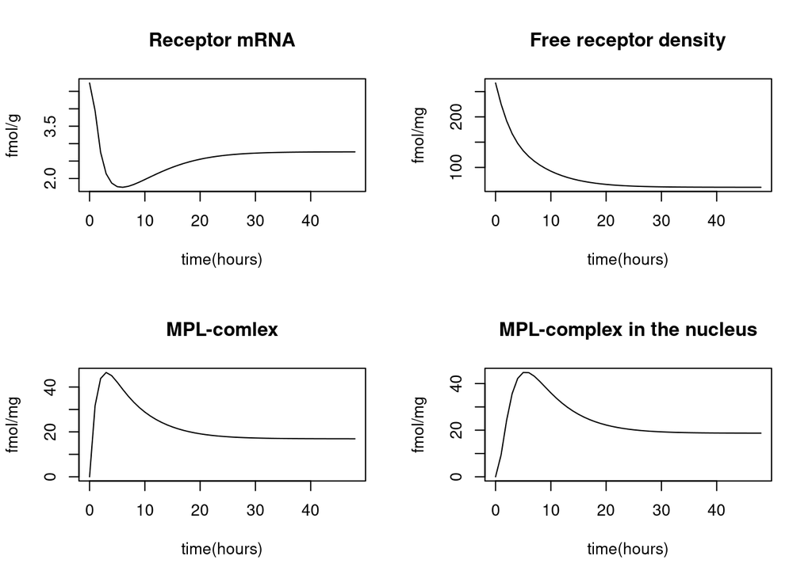

Wanneer de aanmaak en afbraak van het mRNA 5x zo groot wordt dan is er te zien dat de concentratie van het receptor mRNA langzaam daalt, vervolgens weer voorzichtig stijgt en dan een steady state bereikt. In de dichtheid van de vrije receptor zien we een daling totdat de steady state bereikt wordt. Het MPL-complex in zowel het cytoplasma als het complex in de kern ziet eerst een sterke stijging, vervolgens een voorzichtige daling, waarna de steady state bereikt wordt.

```r
parameters[1] <- 2.9*5
parameters[2] <- 2.9*5/4.74
out <- ode(y=state, times=t, func=glucocorticoid, parms=parameters)
plot(out, main=c("Receptor mRNA", "Free receptor density",
                        "MPL-comlex","MPL-complex in the nucleus"),
     ylab = c("fmol/g", "fmol/mg","fmol/mg", "fmol/mg"), xlab = "time(hours)")
```

Het lijkt alsof het groter maken van de ks_Rm niet veel verandering brengt wanneer het vergeleken wordt met de originele staat van het model.

# Discussie and Conclusie

## Discussie

Om de resultaten te produceren is ervoor gekozen om de mediaan van de waardes te gebruiken. Hiervoor is gekozen om te voorkomen dat outliers teveel invloed hebben op de resultaten.

Wat het verschil tussen het model en de data van de experimenten bij de concentratie mRNA receptor zou kunnen verklaren is het feit dat er te weining data is uit het experiment. Voor het verschil tussen beide bij de dichtheid in het vrije receptor comlex kan het aan dezelfde reden liggen. Het kan ook zo zijn dat de expressie van beta vorm van het MPL-complex bindt op de genen waardoor transcriptie wordt gestopt.

Het model is gebaseerd op de vindingen van het artikel van Barnes, dit artikel spreekt over de menselijk reactie op de medicatie. De data van de experimenten komen vanuit ratten, dit kan ook een reden zijn voor het verschil.

Bij de simulaties worden er verschillende dingen gezien als de situaties vergeleken worden met de orginele situatie.

De eerste situatie waar er geen auto regulatie reageerde het model als verwacht, omdat de transcriptie van het mRNA nu niets meer te maken heeft met de auto-regulatie van het gen, is de daling van de hoeveelheid mRNA nu veel minder.

In de tweede situatie wordt er plost gestopt met de medicatie maar omdat er nog wat medicatie in het systeem zit moet dit er eerst langzaam het systeem verlaten. Wanneer alles uit het systeem zijn we dat de waardes terug gaan naar de waardes aan het begin van de periode met medicatie en hier een steady state vormen. Dit komt omdat de medicatie nu niet meer met de receptor bindt en dus niet meer die regulatie kan uitoefenen.

Het model reageerde ook zoals verwacht in de situatie waar de ‘rate of association’ groter wordt gemaakt. Doordat het MPL de receptor sneller bindt, kan er gezien worden dat bijna alles sneller plaatsvindt. Wat niet verwacht was waren de grotere hoeveelheden op de y-as wanneer k_on groter wordt, dit is wel te verwachten als er naar het model gekeken wordt. Opnieuw, omdat de binding sneller plaatsvindt is er meer MPL-complex, er juist minder vrije receptor dichtheid.

Er is niet veel te zeggen over het model wanneer mRNA synthese geblokkeerd wordt, het reageerd zoals wordt verwacht als er naar het model gekeken wordt. Er zijn hier geen gekke resultaten. Als er een stop komt op het mRNA betekent dit dat uiteindelijk alles stopt, geen mRNA voor de receptor betekent geen receptor en betekent dat de medicatie nergens invloed op kan hebben omdat de medicatie bindt op de receptor voordat het kan binden op het glucocorticosteroid response element (GRE).

De laatste situatie spreekt over een situatie wanneer de synthese van mRNA (ks_Rm) kleiner of groter wordt gemaakt. Vanuit de biologie zou een hogere ks_Rm waarde niet veel verschil hebben met een normale waarde, dit komt omdat de regulatie van het mRNA nog steeds werkt. Dit zal uiteindelijk de rem weer op de synthese doen, en dit laat het model ook weer zien. Bij een kleinere ks_Rm waarde zal er minder receptor zijn, en dus zal die regulatie reactie van het MPL-complex minder snel plaatsvinden waardoor de daling in het begin geleidelijker zal gebeuren, ook dit is weer terug te vinden in wat het model gedaan heeft.

## Conclusie

Wanneer het model vergeleken wordt met data uit het veld zijn er punten waarop verbeterd zou kunnen worden. De realiteit ziet er iets minder ‘stabiel’ uit dan het model laat denken.

Als er gekeken wordt vanuit de biologie dan reageert het model zoals verwacht op de scenarios die er zijn gegeven tijdens de simulaties.